# Tipps ’n Tricks für Übungsaufgabe 3 (SPSS)

## Regressionsdiagnostik

Um eine Residuendiagnostik in SPSS durchzuführen, werden die vorhergesagten Werte (Werte der Regressionsgeraden) und die Residuen eines Modells benötigt. Diese können mit den folgenden Codes abgefragt werden:

| Befehl | Description |
| --- | --- |
| PRED | Unstandardisierte vorhergesagte Werte |
| ZPRED | Standardisierte vorhergesagte Werte |
| RESID | Unstandardisierte Residuen |
| ZRESID | Standardisierte Residuen |

Für ein spezifisches Modell können die benötigten Werte folgendermaßen benutzt werden:

```r
REGRESSION
  /DEPENDENT UV
  /METHOD=ENTER AV
  /SAVE RESID ZRESID.
```

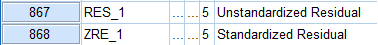

Der Befehl `/SAVE RESID ZRESID` speichert die unstandardisierten und standardisierten Residuen ab und fügt diese an das Ende des Datensatzes.

Will man nun beispielsweise ein Scatterplot mit den Residuen des Modells darstellen, lässt sich das mit `/SCATTERPLOT=(Y, X)` Befehl machen:

[figure not shown]

```r
REGRESSION
  /DEPENDENT UV
  /METHOD=ENTER UV
  /SAVE RESID ZRESID
  /SCATTERPLOT=(*RESID, AV).
```

## Testen der Annahme 3

**Achtung beim Testen der Annahme 3:**

Beim testen der A3, werden die absoluten Werte der Residuen betrachtet, da sich negative und positive Werte über die gesamte Regressionsgerade weitestgehend ausmitteln. Erstellen wir also zunächst eine Residuenvariable welche diese absoluten Werte beinhaltet.

```r
COMPUTE ZRE_1_ABS = ABS(ZRE_1).
```

Jetzt können wir eine (kleine) Korrelationsmatrix erstellen um zu testen ob die Residuen mit den unabhängigen Variablen (bzw. mit den vorhergesagten Werten im mulitvariten Fall) korreliert sind.

```r
CORR UV ZRE_1_ABS.
```

KorrelationenKorrelationen, Tabelle, 1 Stufen von Spaltenüberschriften und 2 Stufen von Zeilenüberschriften, Tabelle mit 4 Spalten und 8 Zeilen

|  |  | Alter mit 18 als Nullpunkt | ZRE_1_ABS |
| --- | --- | --- | --- |
| Alter mit 18 als Nullpunkt | Korrelation nach Pearson | 1 | -,045 |
|  | Signifikanz (2-seitig) |  | ,012 |
|  | N | 3468 | 3064 |
| ZRE_1_ABS | Korrelation nach Pearson | -,045 | 1 |
|  | Signifikanz (2-seitig) | ,012 |  |
|  | N | 3064 | 3064 |

## Testen der Annahme 5

Mit dem Befehl`/RESIDUALS` gefolgt von `HISTOGRAM(ZRESID)` und/oder `NORMPROB(ZRESID)` lässt sich die Normalverteilung der (standardisierten) Residuen visuell überprüfen.

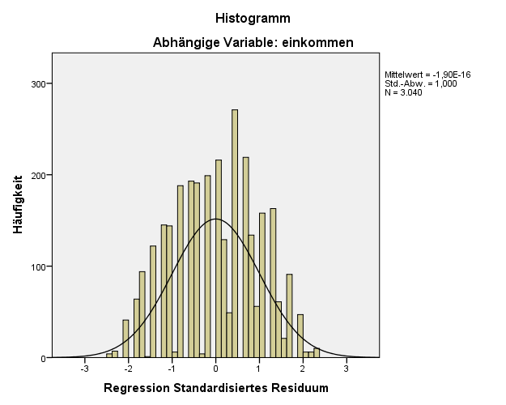

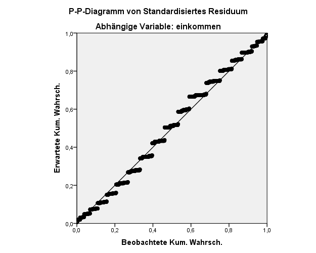

```r
REGRESSION
  /DEPENDENT UV
  /METHOD=ENTER AV
  /RESIDUALS HISTOGRAM(ZRESID) NORMPROB(ZRESID).
```

Der folgende Befehl generiert einen Kolmogorov-Smirnov Test bzw. einen Shapiro-Wilko Test. Beide dieser statistischen Tests überprüfen ob die Verteilung der eingegebenen Variable signifikant von der Normalverteilung abweicht. Ist der Wert signifikant, so kann nicht von einer Normalverteilung ausgegangen werden.

```r
EXAMINE VARIABLES=ZRE_1
  /PLOT NPPLOT.
```

Detaillierte Infos zur Regressionsdiagnostik in SPSS findet ihr auf:

[figure not shown]

[UCLA Institute for Digital Research and Education](https://stats.idre.ucla.edu/spss/seminars/introduction-to-regression-with-spss/introreg-lesson2/)

Fabio Votta

15 November 2018